# Session 1: Exploratory Data Analysis (EDA)

**Project:** Telecom Customer Churn Prediction

**What is this project about?** A telecom company (Vodafone) is losing customers, some people cancel their subscriptions and leave. This is called *churn*. The goal of this project is to use data to predict which customers are likely to leave, so the company can reach out and try to keep them before it's too late.

**What are we doing in this notebook?** Before building any prediction model, we need to understand the data. This notebook is all about *exploring* the dataset, looking at what information we have, cleaning up any problems, and identifying which customer traits are most linked to churn.

By the end of this notebook we can answer:

1. How many customers churned, and what percentage is that?
2. Which customer traits are most strongly linked to churn?
3. Is the data clean, or do we need to fix anything first?

## 1. Imports and Setup

Before writing any analysis code, we load the tools (libraries) we need.

- **pandas**: loads and manipulates data tables (like Excel, but in Python)
- **numpy**: fast math on large lists of numbers
- **matplotlib**: draws charts and graphs
- **seaborn**: prettier statistical charts built on top of matplotlib
- **plotly**: interactive charts you can hover over

```python
import pandas as pd           # pandas: for loading and working with tabular data (like Excel in Python)
import numpy as np            # numpy: for fast math operations on arrays of numbers
import matplotlib.pyplot as plt   # matplotlib: the core plotting library
import seaborn as sns         # seaborn: makes prettier statistical charts on top of matplotlib
import plotly.express as px   # plotly: for interactive charts (you can hover over them)
import warnings

warnings.filterwarnings("ignore")  # hide non-critical warning messages so the output stays clean
sns.set_theme(style="whitegrid", context="talk")  # set a clean visual style for all seaborn charts
plt.rcParams["figure.figsize"] = (10, 6)           # set default chart size: 10 inches wide, 6 inches tall
pd.set_option("display.max_columns", 50)           # show up to 50 columns when printing a dataframe

print("Libraries loaded.")
```

```
Libraries loaded.
```

## 2. Load the Data

We are downloading a spreadsheet directly from the internet (IBM's GitHub page). It contains information about 7,043 telecom customers, things like how long they've been a customer, what services they use, and whether they eventually left.

If the internet download fails for any reason, the code automatically falls back to a local copy saved on your computer. This makes the notebook reliable in both online and offline environments.

```python
DATA_URL = "https://raw.githubusercontent.com/IBM/telco-customer-churn-on-icp4d/master/data/Telco-Customer-Churn.csv"
LOCAL_PATH = "../data/Telco-Customer-Churn.csv"

# Try to download the dataset from the internet first
try:
    df = pd.read_csv(DATA_URL)  # read_csv loads a .csv file into a DataFrame (a table with rows and columns)
    print(f"Loaded from URL: {df.shape[0]} rows, {df.shape[1]} columns")
except Exception as e:
    # If the download fails (no internet, URL changed), fall back to a local copy
    print(f"URL load failed ({e}), trying local file...")
    df = pd.read_csv(LOCAL_PATH)
    print(f"Loaded from local file: {df.shape[0]} rows, {df.shape[1]} columns")

df.head()  # show the first 5 rows so we can see what the data looks like
```

```
Loaded from URL: 7043 rows, 21 columns
```

|  | customerID | gender | SeniorCitizen | Partner | Dependents | tenure | PhoneService | MultipleLines | InternetService | OnlineSecurity | OnlineBackup | DeviceProtection | TechSupport | StreamingTV | StreamingMovies | Contract | PaperlessBilling | PaymentMethod | MonthlyCharges | TotalCharges | Churn |
| --- | --- | --- | --- | --- | --- | --- | --- | --- | --- | --- | --- | --- | --- | --- | --- | --- | --- | --- | --- | --- | --- |
| 0 | 7590-VHVEG | Female | 0 | Yes | No | 1 | No | No phone service | DSL | No | Yes | No | No | No | No | Month-to-month | Yes | Electronic check | 29.85 | 29.85 | No |
| 1 | 5575-GNVDE | Male | 0 | No | No | 34 | Yes | No | DSL | Yes | No | Yes | No | No | No | One year | No | Mailed check | 56.95 | 1889.5 | No |
| 2 | 3668-QPYBK | Male | 0 | No | No | 2 | Yes | No | DSL | Yes | Yes | No | No | No | No | Month-to-month | Yes | Mailed check | 53.85 | 108.15 | Yes |
| 3 | 7795-CFOCW | Male | 0 | No | No | 45 | No | No phone service | DSL | Yes | No | Yes | Yes | No | No | One year | No | Bank transfer (automatic) | 42.30 | 1840.75 | No |
| 4 | 9237-HQITU | Female | 0 | No | No | 2 | Yes | No | Fiber optic | No | No | No | No | No | No | Month-to-month | Yes | Electronic check | 70.70 | 151.65 | Yes |

## 3. First Look at the Data

Before doing any analysis, we always inspect the raw data to answer three basic questions:

- What columns (features) do we have, and what type of data is in each one?
- Are there any missing values we need to deal with?
- Does anything look obviously wrong?

`df.info()` answers the first question. `df.describe()` gives us basic statistics like average, min, and max for every number column.

```python
# df.info() prints a summary of every column:
# - the column name
# - how many non-null (non-missing) values it has out of 7043
# - the data type: int64 = whole number, float64 = decimal number, object = text
df.info()
```

```
<class 'pandas.DataFrame'>
RangeIndex: 7043 entries, 0 to 7042
Data columns (total 21 columns):
 #   Column            Non-Null Count  Dtype
---  ------            --------------  -----
 0   customerID        7043 non-null   str
 1   gender            7043 non-null   str
 2   SeniorCitizen     7043 non-null   int64
 3   Partner           7043 non-null   str
 4   Dependents        7043 non-null   str
 5   tenure            7043 non-null   int64
 6   PhoneService      7043 non-null   str
 7   MultipleLines     7043 non-null   str
 8   InternetService   7043 non-null   str
 9   OnlineSecurity    7043 non-null   str
 10  OnlineBackup      7043 non-null   str
 11  DeviceProtection  7043 non-null   str
 12  TechSupport       7043 non-null   str
 13  StreamingTV       7043 non-null   str
 14  StreamingMovies   7043 non-null   str
 15  Contract          7043 non-null   str
 16  PaperlessBilling  7043 non-null   str
 17  PaymentMethod     7043 non-null   str
 18  MonthlyCharges    7043 non-null   float64
 19  TotalCharges      7043 non-null   str
 20  Churn             7043 non-null   str
dtypes: float64(1), int64(2), str(18)
memory usage: 1.1 MB
```

```python
# df.describe() calculates basic statistics for every numeric column:
# count = how many values exist, mean = average, std = how spread out values are,
# min/max = smallest and largest value, 25%/50%/75% = where the middle values fall
df.describe()
```

|  | SeniorCitizen | tenure | MonthlyCharges |
| --- | --- | --- | --- |
| count | 7043.000000 | 7043.000000 | 7043.000000 |
| mean | 0.162147 | 32.371149 | 64.761692 |
| std | 0.368612 | 24.559481 | 30.090047 |
| min | 0.000000 | 0.000000 | 18.250000 |
| 25% | 0.000000 | 9.000000 | 35.500000 |
| 50% | 0.000000 | 29.000000 | 70.350000 |
| 75% | 0.000000 | 55.000000 | 89.850000 |
| max | 1.000000 | 72.000000 | 118.750000 |

```python
# isnull() marks every missing cell as True, .sum() then counts how many True values per column
# A result of 0 for a column means no missing values, that's what we want
print(f"Missing values per column:{df.isnull().sum()}")
print(f"\nTotal duplicate rows: {df.duplicated().sum()}")  # check if any row appears exactly twice
```

```
Missing values per column:customerID          0
gender              0
SeniorCitizen       0
Partner             0
Dependents          0
tenure              0
PhoneService        0
MultipleLines       0
InternetService     0
OnlineSecurity      0
OnlineBackup        0
DeviceProtection    0
TechSupport         0
StreamingTV         0
StreamingMovies     0
Contract            0
PaperlessBilling    0
PaymentMethod       0
MonthlyCharges      0
TotalCharges        0
Churn               0
dtype: int64

Total duplicate rows: 0
```

## 4. Cleaning the Data

We need to convert `TotalCharges` to a proper number before we can use it in any calculations or modeling.

```python
# pd.to_numeric converts the column from text to numbers
# errors="coerce" means: if a value can't be converted (like an empty string), replace it with NaN (Not a Number)
df["TotalCharges"] = pd.to_numeric(df["TotalCharges"], errors="coerce")

# Count how many NaN values were created by the conversion
n_missing = df["TotalCharges"].isnull().sum()
print(f"Rows with missing TotalCharges after conversion: {n_missing}")

# Show those rows so we can understand WHY they're missing before deciding what to do
df[df["TotalCharges"].isnull()][["customerID", "tenure", "MonthlyCharges", "TotalCharges", "Churn"]]
```

```
Rows with missing TotalCharges after conversion: 11
```

|  | customerID | tenure | MonthlyCharges | TotalCharges | Churn |
| --- | --- | --- | --- | --- | --- |
| 488 | 4472-LVYGI | 0 | 52.55 | NaN | No |
| 753 | 3115-CZMZD | 0 | 20.25 | NaN | No |
| 936 | 5709-LVOEQ | 0 | 80.85 | NaN | No |
| 1082 | 4367-NUYAO | 0 | 25.75 | NaN | No |
| 1340 | 1371-DWPAZ | 0 | 56.05 | NaN | No |
| 3331 | 7644-OMVMY | 0 | 19.85 | NaN | No |
| 3826 | 3213-VVOLG | 0 | 25.35 | NaN | No |
| 4380 | 2520-SGTTA | 0 | 20.00 | NaN | No |
| 5218 | 2923-ARZLG | 0 | 19.70 | NaN | No |
| 6670 | 4075-WKNIU | 0 | 73.35 | NaN | No |
| 6754 | 2775-SEFEE | 0 | 61.90 | NaN | No |

**What we found:** All 11 rows with a missing `TotalCharges` belong to brand-new customers who just signed up, their `tenure` is 0, meaning they've been with the company for 0 months. They haven't received their first bill yet, so their total charge is logically 0.

**Decision:** Fill the missing values with 0 instead of deleting those rows. Deleting real customers from the dataset is almost always the wrong move we want to keep every data point we have.

```python
# fillna(0) replaces every NaN in TotalCharges with the value 0
# We chose 0 because these customers are brand new (tenure = 0) and haven't been billed yet
df["TotalCharges"] = df["TotalCharges"].fillna(0)
print(f"Missing values after fill: {df['TotalCharges'].isnull().sum()}")  # should print 0
```

```
Missing values after fill: 0
```

## 5. How Many Customers Actually Churned?

The column we are trying to predict is called `Churn`, it is either `"Yes"` (the customer left) or `"No"` (the customer stayed).

Before building any model, we need to ask: **is the dataset balanced?** Imagine we had 100 customers and only 1 churned. A lazy model could predict "No" for everyone and be 99% accurate, but it would never catch a single churner! That's why balance matters.

We check here whether we have enough churners in the data for a model to actually learn from them.

```
Churn counts:
Churn
No     5174
Yes    1869
Name: count, dtype: int64

Churn percentage:
Churn
No     73.46
Yes    26.54
Name: proportion, dtype: float64
```

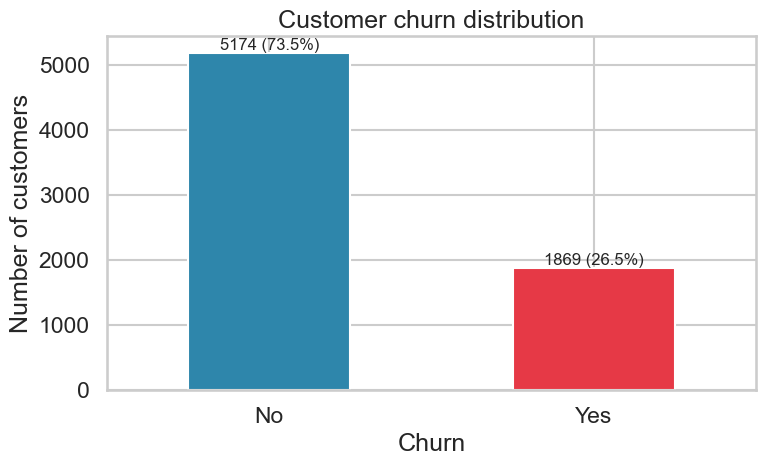

```python
# Count how many customers fall into each group ("No" = stayed, "Yes" = churned)
churn_counts = df["Churn"].value_counts()
# Convert counts to percentages (multiply by 100 to get e.g. 26.5 instead of 0.265)
churn_pct = df["Churn"].value_counts(normalize=True) * 100

print("Churn counts:")
print(churn_counts)
print("\nChurn percentage:")
print(churn_pct.round(2))

# Draw a bar chart to visualise the split
fig, ax = plt.subplots(figsize=(8, 5))
colors = ["#2E86AB", "#E63946"]  # blue = stayed, red = churned
churn_counts.plot(kind="bar", color=colors, ax=ax)
ax.set_title("Customer churn distribution")
ax.set_xlabel("Churn")
ax.set_ylabel("Number of customers")
ax.set_xticklabels(["No", "Yes"], rotation=0)
# Add the exact count and percentage as a text label above each bar
for i, v in enumerate(churn_counts.values):
    ax.text(i, v + 50, f"{v} ({churn_pct.values[i]:.1f}%)", ha="center", fontsize=12)
plt.tight_layout()
plt.show()
```

**What we found:** Out of 7,043 customers, about 1,869 (27%) churned and 5,174 (73%) stayed.

Think of it like this: if 100 customers walk in, 27 of them will eventually leave. That's a meaningful number the company should care about. The dataset is not perfectly balanced, but it's not extreme either, we have plenty of churners for a model to learn from. We just need to be careful to measure the model using **precision, recall, and F1-score** in Session 2, not just accuracy.

## 6. Numerical Features

There are three columns that contain actual numbers (not labels or categories):

- `tenure`: how many months the customer has been with the company
- `MonthlyCharges`: how much they pay per month
- `TotalCharges`: how much they've paid in total since joining

**What we're looking for:** Do churners and non-churners look different on these three numbers? If churners consistently have shorter tenure, for example, that's a pattern our model can use to make predictions.

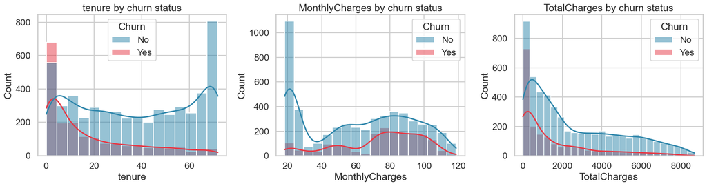

```python
numerical_cols = ["tenure", "MonthlyCharges", "TotalCharges"]

# Create one chart per numerical column, arranged in a single row
fig, axes = plt.subplots(1, 3, figsize=(18, 5))
for ax, col in zip(axes, numerical_cols):
    sns.histplot(
        data=df, x=col,
        hue="Churn",    # colour the bars by churn status: blue = stayed, red = churned
        kde=True,       # add a smooth curve on top to show the overall shape of the distribution
        ax=ax,
        palette={"No": "#2E86AB", "Yes": "#E63946"},
        alpha=0.5       # make bars slightly transparent so overlapping bars are both visible
    )
    ax.set_title(f"{col} by churn status")
plt.tight_layout()
plt.show()
```

**What the charts tell us:**

- **Tenure (how long they've been a customer):** Customers who leave are mostly new. The red (churned) bar spikes at the very left (0–10 months). Long-term customers almost never churn. This is likely the single most powerful feature in the dataset.
- **Monthly Charges (how much they pay per month):** Churners tend to pay more, their red bars cluster on the right side (higher prices). Customers paying under $30/month rarely churn.
- **Total Charges (how much they've paid overall):** Churners have lower totals. That makes complete sense, if they leave early, they haven't had time to accumulate a large total bill.

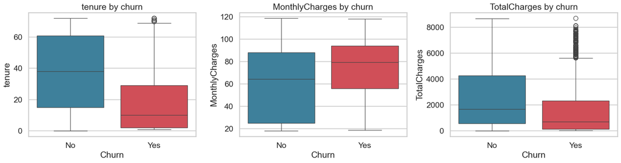

```python
# Box plots for a cleaner side-by-side comparison
fig, axes = plt.subplots(1, 3, figsize=(18, 5))
for ax, col in zip(axes, numerical_cols):
    sns.boxplot(data=df, x="Churn", y=col, ax=ax,
                palette={"No": "#2E86AB", "Yes": "#E63946"})
    ax.set_title(f"{col} by churn")
plt.tight_layout()
plt.show()
```

## 7. Categorical Features

A *categorical* column is one where values are labels or groups, not numbers. For example, the `Contract` column contains "Month-to-month", "One year", or "Two year", three categories.

**What we're looking for:** For each category, what percentage of customers in that group churned? If month-to-month customers churn at 50% but two-year contract customers churn at only 3%, that's a massive signal the model can use.

```python
# Find all columns that contain text (dtype == "object"), but skip the ID column and the target column
# These are our categorical features, the labels and categories we'll analyse
categorical_cols = [c for c in df.columns if df[c].dtype == "object" and c not in ["customerID", "Churn"]]
print(f"Categorical columns ({len(categorical_cols)}):")
print(categorical_cols)
```

```
Categorical columns (0):
[]
```

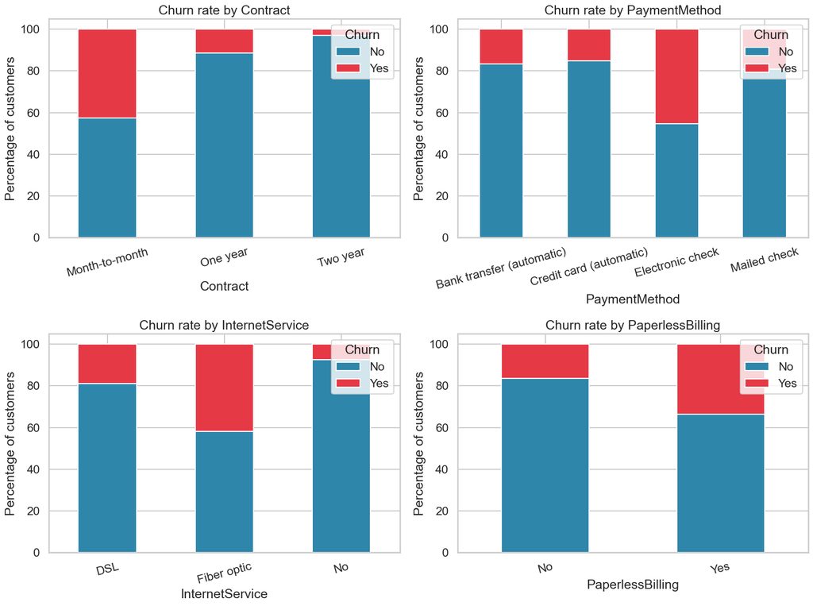

```python
# Start with the four business-critical categories we expect to matter most
key_categoricals = ["Contract", "PaymentMethod", "InternetService", "PaperlessBilling"]

fig, axes = plt.subplots(2, 2, figsize=(16, 12))
for ax, col in zip(axes.flatten(), key_categoricals):
    # pd.crosstab counts customers in each (category, churn) combination
    # normalize="index" converts raw counts to percentages within each category row (each row adds to 100%)
    ct = pd.crosstab(df[col], df["Churn"], normalize="index") * 100
    ct.plot(kind="bar", stacked=True, ax=ax,
            color=["#2E86AB", "#E63946"])  # blue = stayed, red = churned
    ax.set_title(f"Churn rate by {col}")
    ax.set_ylabel("Percentage of customers")
    ax.set_xlabel(col)
    ax.legend(title="Churn", loc="upper right")
    ax.set_xticklabels(ax.get_xticklabels(), rotation=15)
plt.tight_layout()
plt.show()
```

**What the charts tell us:**

- **Contract type:** This is the single strongest signal in the whole dataset. Month-to-month customers churn at a very high rate. Two-year contract customers almost never churn. This makes intuitive sense, someone who committed to two years is clearly more loyal, and it's harder to cancel mid-contract.
- **Payment method:** Customers who pay by electronic check churn much more than those on automatic bank transfer or credit card. A likely reason: automatic payment customers set it and forget it, making them less likely to actively think about cancelling.
- **Internet service:** Fiber optic customers churn more than DSL customers. This seems surprising (fiber is the premium product!), but probably reflects higher prices or customer dissatisfaction with service reliability.
- **Paperless billing:** Customers on paperless billing churn more. This is likely because they also tend to be on month-to-month contracts, the two things go hand-in-hand.

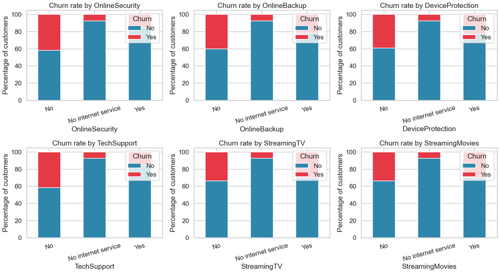

```python
# These six columns represent optional add-on services a customer can subscribe to
service_cols = ["OnlineSecurity", "OnlineBackup", "DeviceProtection", "TechSupport",
                "StreamingTV", "StreamingMovies"]

fig, axes = plt.subplots(2, 3, figsize=(18, 10))
for ax, col in zip(axes.flatten(), service_cols):
    # Same approach: show what % of customers in each category churned
    ct = pd.crosstab(df[col], df["Churn"], normalize="index") * 100
    ct.plot(kind="bar", stacked=True, ax=ax,
            color=["#2E86AB", "#E63946"])
    ax.set_title(f"Churn rate by {col}")
    ax.set_ylabel("Percentage of customers")
    ax.set_xticklabels(ax.get_xticklabels(), rotation=15)
    ax.legend(title="Churn", loc="upper right")
plt.tight_layout()
plt.show()
```

**What the charts tell us:**

Customers who do NOT have `OnlineSecurity` or `TechSupport` churn at a much higher rate than those who do. Why? These add-ons make customers more dependent on the service, if your security and tech support come from this company, it's harder to just leave for a competitor. This is called *stickiness*: the more services a customer relies on, the harder it is for them to leave.

Streaming services (TV and Movies) don't show as strong an effect, probably because those are entertainment options available from many other sources.